# Project Foundations for Data Science: FoodHub Data Analysis

**Marks: 40**

### Context

The number of restaurants in New York is increasing day by day. Lots of students and busy professionals rely on those restaurants due to their hectic lifestyles. Online food delivery service is a great option for them. It provides them with good food from their favorite restaurants. A food aggregator company FoodHub offers access to multiple restaurants through a single smartphone app.

The app allows the restaurants to receive a direct online order from a customer. The app assigns a delivery person from the company to pick up the order after it is confirmed by the restaurant. The delivery person then uses the map to reach the restaurant and waits for the food package. Once the food package is handed over to the delivery person, he/she confirms the pick-up in the app and travels to the customer's location to deliver the food. The delivery person confirms the drop-off in the app after delivering the food package to the customer. The customer can rate the order in the app. The food aggregator earns money by collecting a fixed margin of the delivery order from the restaurants.

### Objective

The food aggregator company has stored the data of the different orders made by the registered customers in their online portal. They want to analyze the data to get a fair idea about the demand of different restaurants which will help them in enhancing their customer experience. Suppose you are hired as a Data Scientist in this company and the Data Science team has shared some of the key questions that need to be answered. Perform the data analysis to find answers to these questions that will help the company to improve the business.

### Data Description

The data contains the different data related to a food order. The detailed data dictionary is given below.

### Data Dictionary

- order_id: Unique ID of the order
- customer_id: ID of the customer who ordered the food
- restaurant_name: Name of the restaurant
- cuisine_type: Cuisine ordered by the customer
- cost: Cost of the order
- day_of_the_week: Indicates whether the order is placed on a weekday or weekend (The weekday is from Monday to Friday and the weekend is Saturday and Sunday)
- rating: Rating given by the customer out of 5
- food_preparation_time: Time (in minutes) taken by the restaurant to prepare the food. This is calculated by taking the difference between the timestamps of the restaurant's order confirmation and the delivery person's pick-up confirmation.
- delivery_time: Time (in minutes) taken by the delivery person to deliver the food package. This is calculated by taking the difference between the timestamps of the delivery person's pick-up confirmation and drop-off information

### Let us start by importing the required libraries

```python
# import libraries for data manipulation
import numpy as np
import pandas as pd

# import libraries for data visualization
import matplotlib.pyplot as plt
import seaborn as sns

%matplotlib inline
```

### Understanding the structure of the data

```python
# uncomment and run the following lines for Google Colab
from google.colab import drive
drive.mount('/content/drive')
```

```python
# read the data
df = pd.read_csv('/content/drive/MyDrive/DSML/Week 2/Project 1/foodhub_order.csv')
# returns the first 5 rows
df.head()
```

|  | order_id | customer_id | restaurant_name | cuisine_type | cost_of_the_order | day_of_the_week | rating | food_preparation_time | delivery_time |
| --- | --- | --- | --- | --- | --- | --- | --- | --- | --- |
| 0 | 1477147 | 337525 | Hangawi | Korean | 30.75 | Weekend | Not given | 25 | 20 |
| 1 | 1477685 | 358141 | Blue Ribbon Sushi Izakaya | Japanese | 12.08 | Weekend | Not given | 25 | 23 |
| 2 | 1477070 | 66393 | Cafe Habana | Mexican | 12.23 | Weekday | 5 | 23 | 28 |
| 3 | 1477334 | 106968 | Blue Ribbon Fried Chicken | American | 29.20 | Weekend | 3 | 25 | 15 |
| 4 | 1478249 | 76942 | Dirty Bird to Go | American | 11.59 | Weekday | 4 | 25 | 24 |

#### Observations:

The DataFrame has 9 columns as mentioned in the Data Dictionary. Data in each row corresponds to the order placed by a customer.

### **Question 1:** How many rows and columns are present in the data?

```python
# storing num of rows and cols for df in variables
df_rows = df.shape[0]
df_cols = df.shape[1]

# printing the number of rows and columns in human readable format
print('There are', df_rows, 'rows and', df_cols, 'columns in the data set.')
```

```
There are 1898 rows and 9 columns in the data set.
```

#### Observations:

There are 1898 rows and 9 columns in the data set.

### **Question 2:** What are the datatypes of the different columns in the dataset? (The info() function can be used)

```python
# Use info() to print a concise summary of the DataFrame
df.info()
```

```
<class 'pandas.core.frame.DataFrame'>
RangeIndex: 1898 entries, 0 to 1897
Data columns (total 9 columns):
 #   Column                 Non-Null Count  Dtype
---  ------                 --------------  -----
 0   order_id               1898 non-null   int64
 1   customer_id            1898 non-null   int64
 2   restaurant_name        1898 non-null   object
 3   cuisine_type           1898 non-null   object
 4   cost_of_the_order      1898 non-null   float64
 5   day_of_the_week        1898 non-null   object
 6   rating                 1898 non-null   object
 7   food_preparation_time  1898 non-null   int64
 8   delivery_time          1898 non-null   int64
dtypes: float64(1), int64(4), object(4)
memory usage: 133.6+ KB
```

#### Observations:

Data types consist of integers (identification fields, and time fields in minutes), objects (restaurant names, cuisine types, week day, and rating), as weel as float (order cost).

### **Question 3:** Are there any missing values in the data? If yes, treat them using an appropriate method

```python
# double checking for null values
df.isna().sum()
```

```
order_id                 0
customer_id              0
restaurant_name          0
cuisine_type             0
cost_of_the_order        0
day_of_the_week          0
rating                   0
food_preparation_time    0
delivery_time            0
dtype: int64
```

#### Observations:

There are no missing values in the data set. There are 1898 entries and each column has 1898 non-null values.

### **Question 4:** Check the statistical summary of the data. What is the minimum, average, and maximum time it takes for food to be prepared once an order is placed?

```python
# finding min, max and avg prep time, stored as variables
min_prep_time = df['food_preparation_time'].min()
max_prep_time = df['food_preparation_time'].max()
avg_prep_time = df['food_preparation_time'].mean()

# printing prep time stats in human readable format
print(
    'Minimum food prep time is:', min_prep_time, 'minutes.', '\n'
    'Maximum food prep time is:', max_prep_time, 'minutes.','\n'
    'Average food prep time is:', avg_prep_time.round(2), 'minutes.','\n'
)
```

```
Minimum food prep time is: 20 minutes.
Maximum food prep time is: 35 minutes.
Average food prep time is: 27.37 minutes.
```

```python
# using .describe() for a more concise summary of food preparation time
df['food_preparation_time'].describe().round(2)
```

```
count    1898.00
mean       27.37
std         4.63
min        20.00
25%        23.00
50%        27.00
75%        31.00
max        35.00
Name: food_preparation_time, dtype: float64
```

#### Observations:

Minimum food prep time is: 20 minutes. Maximum food prep time is: 35 minutes. Average food prep time is: 27.37 minutes.

### **Question 5:** How many orders are not rated?

```python
# finding the counts of unique values for the rating column
df['rating'].value_counts()
```

```
Not given    736
5            588
4            386
3            188
Name: rating, dtype: int64
```

```python
# finding the counts of unique values for the rating column as a percentage
df['rating'].value_counts(normalize=True).round(2)
```

```
Not given    0.39
5            0.31
4            0.20
3            0.10
Name: rating, dtype: float64
```

#### Observations:

Out of 1898 orders, 736 customers did not give a rating, which is approximately 39%.

### Exploratory Data Analysis (EDA)

### **Question 6:** Explore all the variables and provide observations on their distributions. (Generally, histograms, boxplots, countplots, etc. are used for univariate exploration)

### Exploration of Customers:

```python
# creating new series of number of orders per customer
customers_orders = df.customer_id.value_counts()
```

```python
# display first 5 entries for customers_orders
customers_orders.head()
```

```
52832     13
47440     10
83287      9
250494     8
259341     7
Name: customer_id, dtype: int64
```

```python
# using .describe() to see info on the customer base
customers_orders.describe()
```

```
count    1200.000000
mean        1.581667
std         1.090560
min         1.000000
25%         1.000000
50%         1.000000
75%         2.000000
max        13.000000
Name: customer_id, dtype: float64
```

```python
# finding the mode for number of orders/customer
customers_orders.mode()
```

```
0    1
Name: customer_id, dtype: int64
```

```python
# converting series to dataframe
df_orders = customers_orders.to_frame()
```

```python
# looking at first 5 rows of data
df_orders.head()
```

|  | customer_id |
| --- | --- |
| 52832 | 13 |
| 47440 | 10 |
| 83287 | 9 |
| 250494 | 8 |
| 259341 | 7 |

```python
#overwriting column name to be num_orders, not customer_id
df_orders.rename(columns={'customer_id': 'num_orders'}, inplace=True)
```

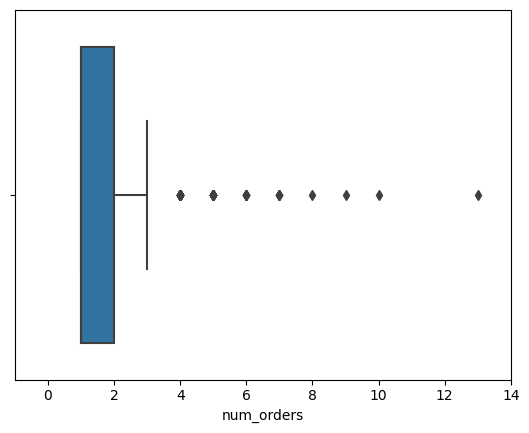

```python
# creating a box plot showing the number of orders per unique customer
sns.boxplot(data=df_orders, x='num_orders')
plt.xlim(-1,14);
```

#### Observations of orders per customer:

There are 1200 unique customers. On average, each customer has made 1.6 orders, however most customers have made just one order through the app. There are a few outliers, with the highest number of orders from a single customer being 13.

### Exploration of Restaurant Name:

```python
# finding number of unique values for each category
df.nunique(0)
```

```
order_id                 1898
customer_id              1200
restaurant_name           178
cuisine_type               14
cost_of_the_order         312
day_of_the_week             2
rating                      4
food_preparation_time      16
delivery_time              19
dtype: int64
```

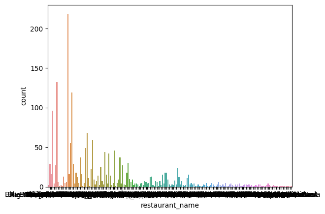

```python
# creating count plot of orders per restaurant
sns.countplot(data=df, x='restaurant_name')
plt.show()
```

#### Initial Observations of Restarant Name

Ther are 178 unique restaurants customers have ordered from, which makes for a very crowded count plot.

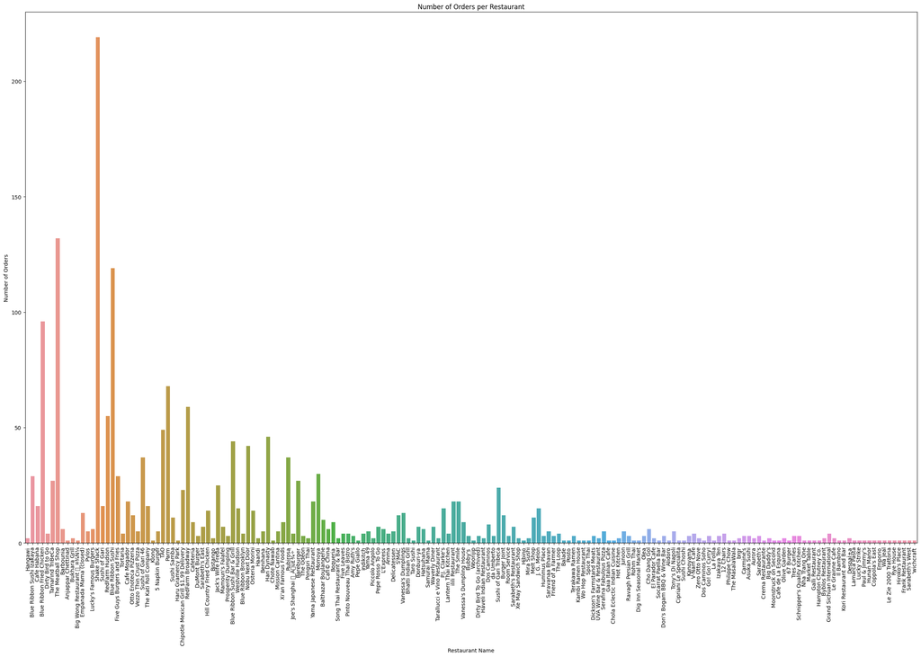

```python
# creating a more readable count plot
plt.figure(figsize=(30,18))
sns.countplot(data=df, x='restaurant_name')
plt.xticks(rotation=90)
plt.title('Number of Orders per Restaurant')
plt.xlabel('Restaurant Name')
plt.ylabel('Number of Orders');
```

#### Observations

While still crowded, we are able to extract some info and see that Shake Shack, Blue Ribbon sushi and the meatball shop are among the most popular.

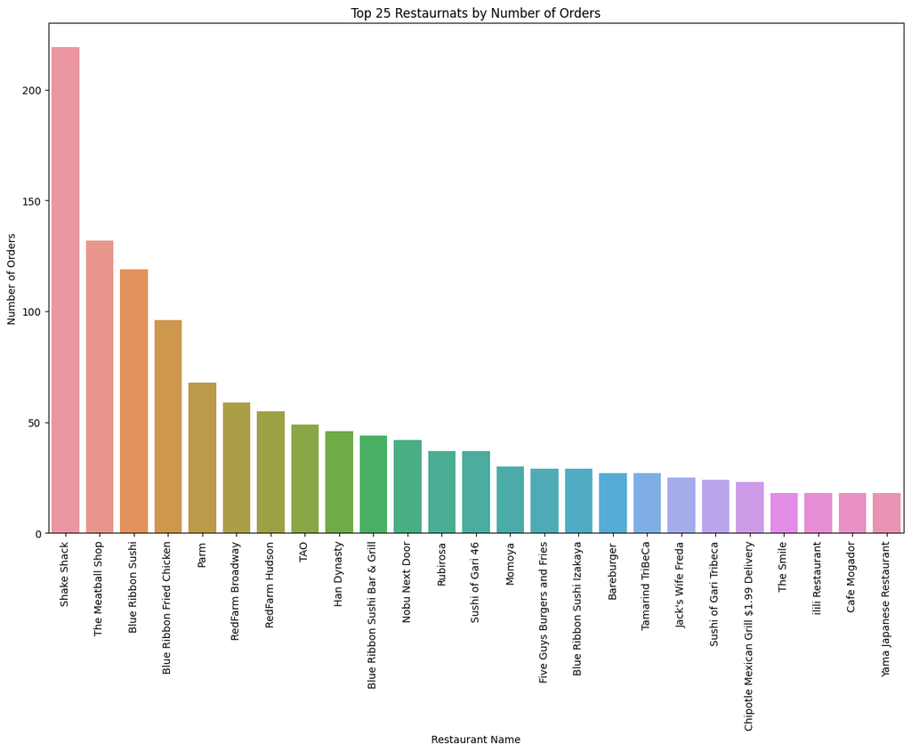

```python
# creating a count plot of the top 25 most popular restaurants
plt.figure(figsize=(15,9))
sns.countplot(data=df, x='restaurant_name',
              order=df.restaurant_name.value_counts().iloc[:25].index)
plt.xticks(rotation=90)
plt.title('Top 25 Restaurnats by Number of Orders')
plt.xlabel('Restaurant Name')
plt.ylabel('Number of Orders');
```

#### Observations

Here we can more easily see the most popular restaurants, in descending order.

```python
# creating a series of restaurants and order numbers
restaurant_orders = df.restaurant_name.value_counts()
restaurant_orders
```

```
Shake Shack                  219
The Meatball Shop            132
Blue Ribbon Sushi            119
Blue Ribbon Fried Chicken     96
Parm                          68
                            ...
Sushi Choshi                   1
Dos Caminos Soho               1
La Follia                      1
Philippe Chow                  1
'wichcraft                     1
Name: restaurant_name, Length: 178, dtype: int64
```

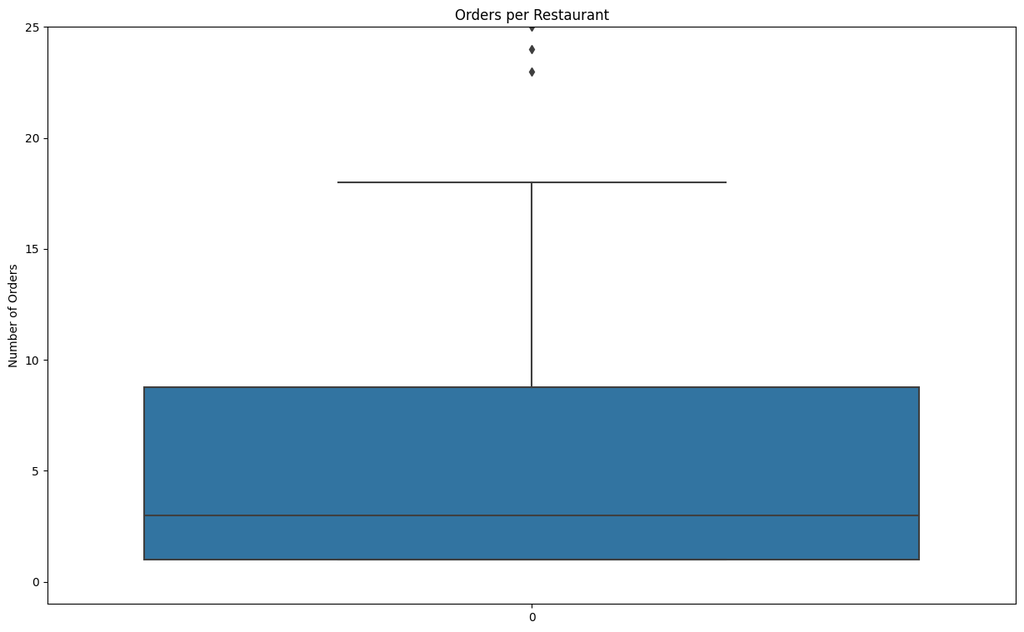

```python
# creating a count plot of the top 25 most popular restaurants
plt.figure(figsize=(15,9))
sns.boxplot(data=restaurant_orders)
plt.title('Orders per Restaurant')
plt.ylabel('Number of Orders')
plt.ylim(-1,25);
```

#### Observations:

The large majority of restaurants have had less than about 18 orders. Restaurants that have more orders than 20 are considered outliers.